# Warp centering

### The issue

Group registration produces J warps γ_i and registered observations y_i∘γ_i. The registered observations live on the time axis of the **template**, but the template's own timing is arbitrary: it depends on which observation seeded the iteration, on the method, and on the initial cross-sectional mean. Any common warp η can be applied to all γ_i (γ_i ↦ γ_i∘η) without changing the *relative* alignment of the observations; it only changes the time axis on which the registered data and the template are reported. Iterating the template (registering to an arbitrary template, replacing it by the mean of the registered curves, and repeating) removes the seed's influence on the template's *shape*, but not on its *timing*: the alignment cost is invariant to a common warp, so the iteration cannot detect a timing bias, let alone remove it.

**Centering** picks one representative from the family {γ_i∘η}: each warp is composed with the inverse of a common reference warp, γ_i ↦ γ_i∘w_ref⁻¹, and the reference is chosen so that the registered data have a meaningful common time axis.

### The decision

Every nonlinear `register_*` function has a `center` keyword with the same four options (`reg1d.warp.center_warps`):

| `center=` | reference warp w_ref | default for |
| --- | --- | --- |
| `'karcher'` | Karcher (Fréchet) mean of the warps under the Fisher–Rao metric; afterwards the Karcher mean of the warps is the identity, i.e. the registered data have the average timing of the sample | SRSF, continuous, self-modelling, pairwise, Bayesian (all produce invertible warps) |
| `'pointwise'` | arithmetic (pointwise) mean of the warps; well defined also for warps with flat segments | DTW (raw DTW paths may contain horizontal runs, γ′ = 0, for which the Karcher mean is degenerate) |
| `'anchor'` | a monotone warp chosen so that a user-specified event keeps its mean time (`anchor=` a (J,) array of event times, or `'max'` / `'min'`) | — (offered as an explicit choice) |
| `'none'` | identity: no centering; the registered data keep the template's time axis | landmark registration (mean targets already anchor the registered data at the landmarks, which *is* the anchor convention) |

`center=True` selects the method's default and `center=False` is `'none'`, so that any procedure can be run uncentred for comparison. The method used is recorded in `result.info['center']`.

```python
import sys, os
sys.path.insert(0, os.path.abspath('../src'))   # so that this notebook finds registration1d without installation
import numpy as np
from matplotlib import pyplot as plt
import registration1d as reg1d
import util                                      # notebooks/util.py: example datasets and permutation tests
print('registration1d version:', reg1d.__version__)
```

```
registration1d version: 0.0.2
```

```python
dataset = util.Dorn2012()
speed   = dataset.group
yi      = reg1d.register_linear(dataset.y, n=101).y
colors  = ['k','b','g','r']
t       = np.linspace(0, 1, 101)

def show(results, titles):
    fig,AX = plt.subplots(len(results), 3, figsize=(15, 3.6*len(results)))
    AX = np.atleast_2d(AX)
    for row,(r,name) in enumerate(zip(results, titles)):
        reg1d.plot.plot_curves(r.y, group=speed, ax=AX[row,0], colors=colors, x='percent', legend=(row==0)); AX[row,0].set_title(f'{name}: registered')
        r.warps.plot(ax=AX[row,1], group=speed, colors=colors, legend=False)
        AX[row,1].plot(t, r.warps.mean().w, 'm', lw=3, label='Karcher mean'); AX[row,1].plot(t, r.warps.asarray().mean(axis=0), 'c--', lw=2, label='pointwise mean'); AX[row,1].legend(); AX[row,1].set_title(f'{name}: warps')
        reg1d.plot.plot_displacement_fields(r.warps.asarray(), group=speed, ax=AX[row,2], colors=colors, legend=False); AX[row,2].set_title(f'{name}: displacement fields')
    plt.tight_layout(); plt.show()

def report(r, name):
    g = r.warps.asarray()
    print(f"{name:32s} center={r.info['center']:9s} |Karcher mean - id|max = {np.abs(reg1d.warp.karcher_mean_warp(g)-t).max():.4f}   "
          f"|pointwise mean - id|max = {np.abs(g.mean(axis=0)-t).max():.4f}   mean peak time = {np.argmax(r.y,axis=1).mean():.2f} % (original {np.argmax(yi,axis=1).mean():.2f} %)")
```

### 1. SRSF: the four options

```
SRSF, center='karcher'           center=karcher   |Karcher mean - id|max = 0.0002   |pointwise mean - id|max = 0.0021   mean peak time = 71.62 % (original 71.75 %)
SRSF, center='pointwise'         center=pointwise |Karcher mean - id|max = 0.0019   |pointwise mean - id|max = 0.0000   mean peak time = 72.00 % (original 71.75 %)
SRSF, center='anchor'            center=anchor    |Karcher mean - id|max = 0.0159   |pointwise mean - id|max = 0.0173   mean peak time = 72.00 % (original 71.75 %)
SRSF, center='none'              center=none      |Karcher mean - id|max = 0.0263   |pointwise mean - id|max = 0.0276   mean peak time = 70.25 % (original 71.75 %)
```

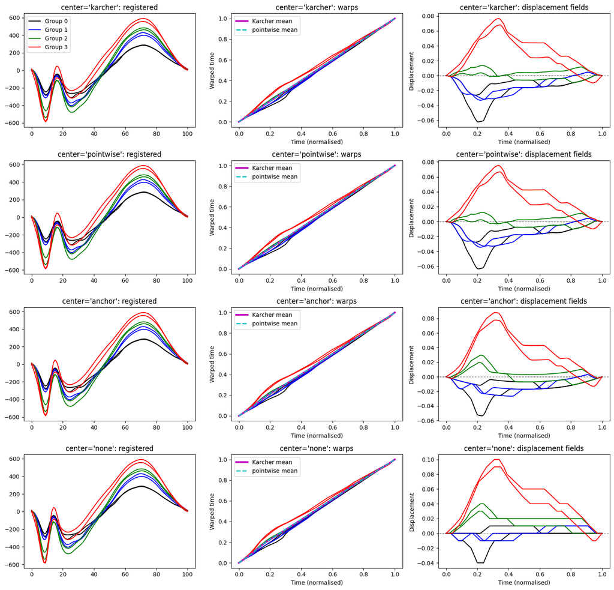

```python
res = {c: reg1d.register_srsf(yi, max_iter=5, center=c, anchor='max') for c in ('karcher', 'pointwise', 'anchor', 'none')}
for c,r in res.items():
    report(r, f'SRSF, center={c!r}')
show(list(res.values()), [f"center='{c}'" for c in res])
```

### 2. Why it matters: displacement-field statistics

A two-sample test on displacement fields (the nlreg1d timing test) compares group means of d_i(t). A common warp adds (approximately) the same displacement to every observation, so a *difference* between groups is nearly invariant to centering — but the individual displacement fields, one-sample questions ("is this group's timing different from linear time?"), and comparisons between methods or studies are not. Centering makes the reference the average timing of the sample, the only choice that does not depend on an arbitrary observation.

```python
groupAB = np.where(speed <= 1, 0, 1)         # slow (0,1) vs fast (2,3)
for c,r in res.items():
    d  = r.displacement_fields
    tt = util.permutation_ttest2(d[groupAB==0], d[groupAB==1], n_perm=500, random_state=0)
    one = np.abs(d.mean(axis=0)).max()
    print(f"center={c!r:12s}: two-sample max|t| = {np.abs(tt['t']).max():.2f} (p = {tt['p']:.3f}, clusters {tt['clusters']});   max |mean displacement| = {one:.4f}")
```

```
center='karcher'   : two-sample max|t| = 5.53 (p = 0.042, clusters [(5, 29)]);   max |mean displacement| = 0.0068
center='pointwise' : two-sample max|t| = 5.56 (p = 0.042, clusters [(5, 29)]);   max |mean displacement| = 0.0065
center='anchor'    : two-sample max|t| = 5.40 (p = 0.042, clusters [(6, 29)]);   max |mean displacement| = 0.0141
center='none'      : two-sample max|t| = 5.41 (p = 0.042, clusters [(5, 29)]);   max |mean displacement| = 0.0281
```

### 3. DTW: pointwise mean by default, Karcher mean once the warps are diffeomorphic

Raw DTW warps (`symmetric2`) have flat segments; their Karcher mean is still computable but the inverse of a flat warp is not unique, so the pointwise mean is the default. With `step_pattern='strict'` and/or `smooth>0` the warps are strictly increasing and `'karcher'` behaves as for SRSF.

```
DTW symmetric2                   center=pointwise |Karcher mean - id|max = 0.0166   |pointwise mean - id|max = 0.0000   mean peak time = 69.12 % (original 71.75 %)
DTW symmetric2                   center=karcher   |Karcher mean - id|max = 0.0138   |pointwise mean - id|max = 0.0299   mean peak time = 68.75 % (original 71.75 %)
DTW strict+smooth                center=pointwise |Karcher mean - id|max = 0.0025   |pointwise mean - id|max = 0.0000   mean peak time = 71.75 % (original 71.75 %)
DTW strict+smooth                center=karcher   |Karcher mean - id|max = 0.0002   |pointwise mean - id|max = 0.0027   mean peak time = 71.75 % (original 71.75 %)
DTW symmetric2                   center=none      |Karcher mean - id|max = 0.0716   |pointwise mean - id|max = 0.0831   mean peak time = 69.75 % (original 71.75 %)
minimum warp slope, symmetric2: 0.0   strict+smooth: 0.0038
```

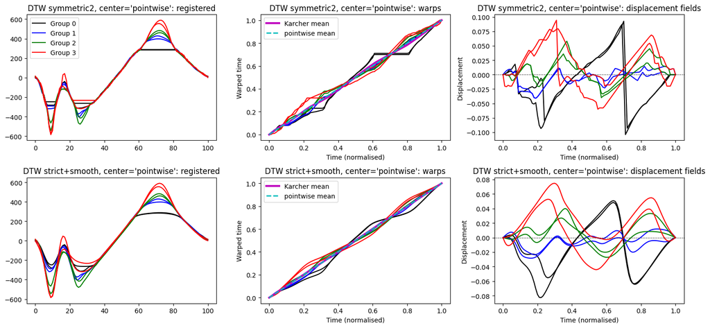

```python
r1 = reg1d.register_dtw(yi)                                                   # default: pointwise
r2 = reg1d.register_dtw(yi, center='karcher')
r3 = reg1d.register_dtw(yi, step_pattern='strict', smooth=0.03)               # pointwise
r4 = reg1d.register_dtw(yi, step_pattern='strict', smooth=0.03, center='karcher')
r5 = reg1d.register_dtw(yi, center=False)
for r,name in [(r1,'DTW symmetric2'),(r2,'DTW symmetric2'),(r3,'DTW strict+smooth'),(r4,'DTW strict+smooth'),(r5,'DTW symmetric2')]:
    report(r, name)
print('minimum warp slope, symmetric2:', np.gradient(r1.warps.asarray(), axis=1).min().round(4), '  strict+smooth:', np.gradient(r3.warps.asarray(), axis=1).min().round(4))
show([r1, r3], ["DTW symmetric2, center='pointwise'", "DTW strict+smooth, center='pointwise'"])
```

### 4. Landmark registration: mean targets are the anchor convention

With `targets='mean'` every landmark is moved to its mean time across observations, so the registered data are anchored to the sample's average timing *at the landmarks* by construction. This is the `'anchor'` convention applied at K events at once; its Karcher mean is close to, but not exactly, the identity. Other centering methods would move the landmarks off their targets and are offered only for comparison.

```python
r_lm  = reg1d.register_landmark(yi, kinds=('zero','max'))                    # default: none (mean targets)
r_lmk = reg1d.register_landmark(yi, kinds=('zero','max'), center='karcher')
for r,name in [(r_lm,'landmark, mean targets'),(r_lmk,'landmark, then Karcher')]:
    report(r, name)
    print('    SD of peak time after registration (%):', np.argmax(r.y, axis=1).std().round(2))
```

```
landmark, mean targets           center=none      |Karcher mean - id|max = 0.0002   |pointwise mean - id|max = 0.0002   mean peak time = 71.75 % (original 71.75 %)
    SD of peak time after registration (%): 0.43
landmark, then Karcher           center=karcher   |Karcher mean - id|max = 0.0000   |pointwise mean - id|max = 0.0002   mean peak time = 71.75 % (original 71.75 %)
    SD of peak time after registration (%): 0.43
```

### 5. The other methods

Continuous, self-modelling, pairwise-synchronisation and Bayesian registration all produce strictly increasing warps and default to `'karcher'`; for Bayesian registration the reference warp is computed from the posterior-mean warps and applied to every posterior sample, so the credible bands are reported on the same axis. Pairwise synchronisation is template-free and its warps are already nearly centred (the mean of the pairwise warps is close to the identity); Karcher centering makes this exact.

```python
for name,fn in [('continuous', lambda c: reg1d.register_continuous(yi, n_basis=6, center=c)),
                ('sim',        lambda c: reg1d.register_sim(yi, n_basis=6, max_iter=3, center=c)),
                ('pairwise',   lambda c: reg1d.register_pairwise(yi, center=c))]:
    for c in ('karcher', 'none'):
        report(fn(c), f'{name}')
```

```
continuous                       center=karcher   |Karcher mean - id|max = 0.0000   |pointwise mean - id|max = 0.0007   mean peak time = 71.88 % (original 71.75 %)
```

```
continuous                       center=none      |Karcher mean - id|max = 0.0042   |pointwise mean - id|max = 0.0041   mean peak time = 71.88 % (original 71.75 %)
```

```
sim                              center=karcher   |Karcher mean - id|max = 0.0000   |pointwise mean - id|max = 0.0007   mean peak time = 71.88 % (original 71.75 %)
```

```
sim                              center=none      |Karcher mean - id|max = 0.0019   |pointwise mean - id|max = 0.0018   mean peak time = 71.88 % (original 71.75 %)
```

```
pairwise                         center=karcher   |Karcher mean - id|max = 0.0002   |pointwise mean - id|max = 0.0013   mean peak time = 71.88 % (original 71.75 %)
```

```
pairwise                         center=none      |Karcher mean - id|max = 0.0112   |pointwise mean - id|max = 0.0103   mean peak time = 72.00 % (original 71.75 %)
```

### Summary

- Centering changes only the common time axis, never the relative alignment.
- `'karcher'` is the default wherever warps are invertible; `'pointwise'` is the default for raw DTW; landmark registration is anchored through its mean targets; `'anchor'` is available everywhere for an event-based reference; `center=False` gives the uncentred result for comparison.
- For displacement-field statistics the between-group difference is nearly invariant to the choice, but one-sample statements and comparisons across methods or studies require a reproducible convention — which is what the defaults provide.